# Church Slavonic words distribution in historical secular texts

Salnikov Egor

### Introduction

The initial hypothesis of the research is the assumption that the lexemes of Church Slavonic language were somehow grouped in non-church texts and became a part of larger semantical chunks than just an isolated word.

There are several types of Church Slavonic lexemes in the Russian language. For this research only two particular oppositions were chosen – plenophonic (neutral lexemes) vs. nonpleophonic (church) and words with [ч’:] (neutral lexemes) vs. words [ш’:] (church). I decided to concentrate on those two particular cases because for every word-pair orthography is different while their meaning is the same. That is why there should be no preference for which one to use. However, in some cases, there is a Church Slavonic words where neutral one can be easily used.

The main goal of the project is to test whether the presence of lexemes of Church Slavonic in the sentence could affect the probability of another Church Slavonic lexemes in the same sentence. In Modern Russian such lexemes are often a part of idiomatic phrases and it should be interesting to track when the idiomatisation process had started.

### Data

Data frame used in the research was compiled from texts from RNC Middle-Russian Corpus. The corpus is annotated in standard Universal Dependencies format, which makes it relatively easy to extract particular data. Metadata contains century and thematic domain for every text – two variables needed for the experiment purity. Data were preprocessed and compiled into the dataframe using Python, and, later on, R to drop some biased variable from the dataframe. The dataframe contains 4 columns: century, th.domain, targ.word, and oth.words. Century column shows the century of the particular text. It is a numerical variable from 15 to 17, which corresponds to the exact century the text belongs to. Th.domain stands for thematic domain and had 4 possible values: business, official, common, and hybrid. However, the fourth type of text (hybrid) was excluded later, because this particular thematic domain might have some Church Slavonic texts in it. Targ.word stands for target word. The column contains target lexemes coded into binary opposition - ‘church’ and ‘non-church’. During preprocessing two nearly synonymous lists were created: one for Church Slavonic lexemes and another one for their neutral alternatives. As a result, 8 pairs were chosen, with each differs in orthography, but also has somewhat synonymous lexical meaning. If there were a word from any of these lists in the parsed sentence, a new row with a value ‘church’ or ‘non-church’ was created in the dataframe.

```r
words <- matrix(c('нощь', 'дщерь', 'град', 'хладный', 'врагъ', 'брегъ', 'сребро', 'древо', 'ночь', 'дочь', 'город', 'холодный', 'ворогъ', 'берегъ', 'серебро', 'дерево'),ncol=8, byrow=TRUE)
rownames(words) <- c('church', 'non-church')
words <- as.table(words)
print(words)
```

```
##            A    B     C     D        E      F      G       H
## church     нощь дщерь град  хладный  врагъ  брегъ  сребро  древо
## non-church ночь дочь  город холодный ворогъ берегъ серебро дерево
```

Oth.words column contains some other common church slavonic words in the sentence. For this purpose, texts from Church Slavonic thematic domain of RNC Middle-Russian Corpus were analyzed to compile the list of the most common Church Slavonic words, which was later filtered to exclude some neutral lexemes.

This list consists of words: аще, мя, паче, прииде, бяше, яко, бо, убо, бысть, еже, рече, тако, святаго, иже, якоже, преподобнаго

The oth.words column shows the number of words from this list found in the examined sentence.

There happen to be a bias in the provided data, which came from the specificity of the corpus: there are just a lot more business texts in it than official and common ones. Because of such thematic bias not every possible combination of century-thematic domain was presented:

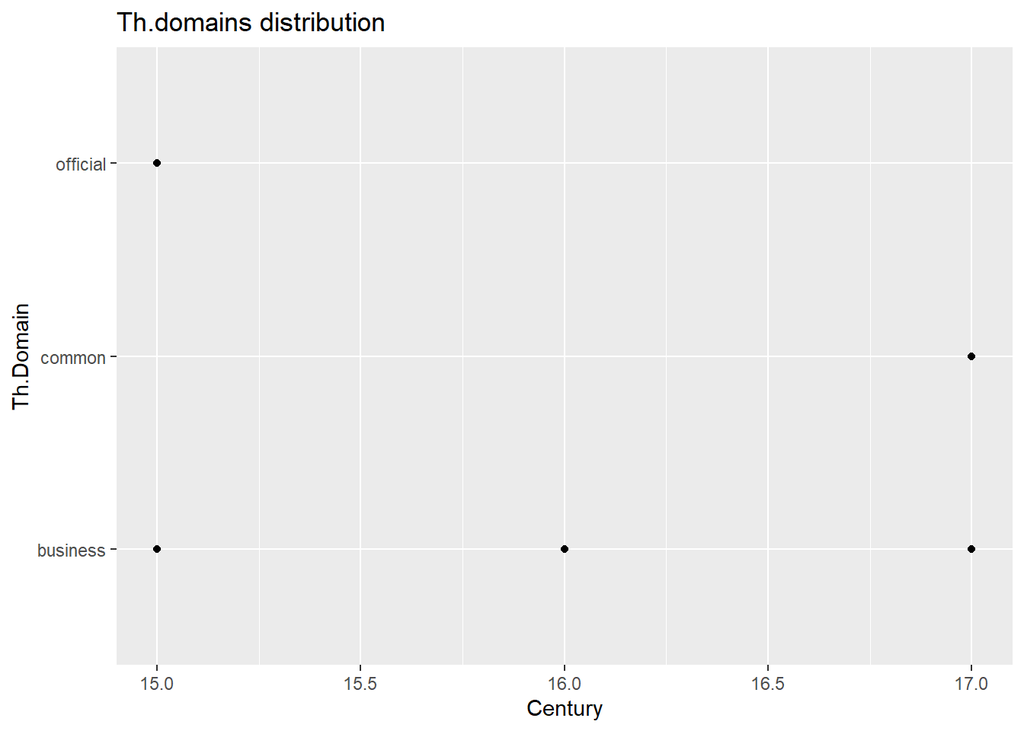

```r
ggplot(data = slavdf, aes(x = century, y = th.domain)) +
  geom_point() +
  labs(x = "Century",
       y = "Th.Domain",
       title = "Th.domains distribution")
```

Also there is a disbalance of data presented by centuries too. 15th c. is represented very poorly with only 87 texts vs. 563 for 16th c. and 522 for 17th c.:

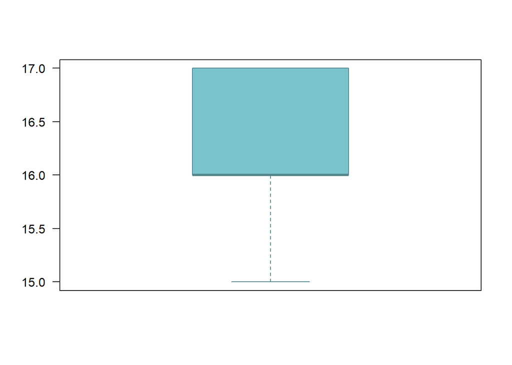

```r
boxplot(slavdf$century,
names = c("century"),
las = 2,
col = c("cadetblue3","black"),
border = "cadetblue4",
horizontal = FALSE,
notch = FALSE
)
```

Here are some quantitative statistics considering century- and thematic domain-variables:

```r
st <- matrix(c(50, 563, 507, 0, 0, 15, 37, 0, 0),ncol=3, byrow=TRUE)
colnames(st) <- c(15, 16, 17)
rownames(st) <- c('business', 'common', 'official')
st <- as.table(st)
print(st)
```

```
##           15  16  17
## business  50 563 507
## common     0   0  15
## official  37   0   0
```

However such bias shouldn’t affect the overall quality of the research, because it concerns only century- and th.domain-variable and not the main variable incpected in the paper - oth. words. It surely can be considered as a flaw making any conclusions about century- and th.domain-variable effect very doubtful. But, as was stated earlier, the main goal of the research is to test if other Church Slavonic lexemes affect the probability of finding another one in the same sentence or not.

### Method

In terms of statistics the initial hypothesis can be formalized as follows:

$H_0$: variables are insignificant

$b_1$ = 0

$b_2$ = 0

$b_3$ = 0

HA: some variable(s) is/are significant

$b_1$ ≠ 0

or/and

$b_2$ ≠ 0

or/and

$b_3$ ≠ 0

To test the initial hypothesis I decided to use probabilistic models. “church” and “non-church” tags in the targ.word column were encoded as 1 and 0 respectively. 7 probit models were built to predict the probability of Church Slavonic lexeme appearance in a particular sentence. Each model uses from 1 to 3 variables (all possible combinations of century-, th.domain-, and oth.words-variables) to predict targ.word.

The probit regression formula is:

P = $b_0$ + $b_1$E + $b_2$T + $b_3$C, where

P - probability of target lexeme presence in the sentence

E - the number of other Church Slavonic lexemes in the sentence

T - thematical domain of the text

C - century of the text

Here are the formulas for every model:

model_all_var: targ.word ~ century + th.domain + oth.words

model_century_th.domain: targ.word ~ century + th.domain

model_oth.words_century: targ.word ~ oth.words + century

model_oth.words_th.domain: targ.word ~ oth.words + th.domain

model_century: targ.word ~ century

model_oth.words: targ.word ~ oth.words

model_th.domain: targ.word ~ th.domain

### Results

Taking a closer look at models’ outputs we should admit that the initial hypothesis has been confirmed. Oth.words is the only variable significant for every model. Its p-value is <2e-16 for every model it was used in. The coefficient of oth.words-variable is positive every time, which means there is a strong positive correlation between the probability of target-Church Slavonic word in the sentence and the number of other Church Slavonic words in it.

Here one can see the all variable model’s output:

```r
summary(model_all_var)
```

```
##
## Call:
## glm(formula = targ.word ~ century + th.domain + oth.words, family = binomial(link = "probit"),
##     data = slavdf)
##
## Deviance Residuals:
##     Min       1Q   Median       3Q      Max
## -4.7644  -0.0642  -0.0385  -0.0385   1.0345
##
## Coefficients:
##                   Estimate Std. Error z value Pr(>|z|)
## (Intercept)        -8.1193     3.9894  -2.035   0.0418 *
## century             0.3088     0.2391   1.291   0.1966
## th.domaincommon    -1.1902     9.2738  -0.128   0.8979
## th.domainofficial  -2.2630   257.8623  -0.009   0.9930
## oth.words           3.7032     0.3207  11.547   <2e-16 ***
## ---
## Signif. codes:  0 '***' 0.001 '**' 0.01 '*' 0.05 '.' 0.1 ' ' 1
##
## (Dispersion parameter for binomial family taken to be 1)
##
##     Null deviance: 473.529  on 1171  degrees of freedom
## Residual deviance:  78.146  on 1167  degrees of freedom
## AIC: 88.146
##
## Number of Fisher Scoring iterations: 17
```

*for other models check Rmd-file with code

However, the significance of century- and th.domain-variables is not so clear. It could be caused by the bias in data, illustrated above.

Century variable, on the other hand, becomes significant in some 2-variable models and has a positive coefficient. Sadly, it also can be explained by data bias. 15th century contains only 87 texts, while 16th contains 563, and 17th - 522. So this ‘pseudo’-positive correlation is a result of most of the texts being grouped by 16th and 17th century.

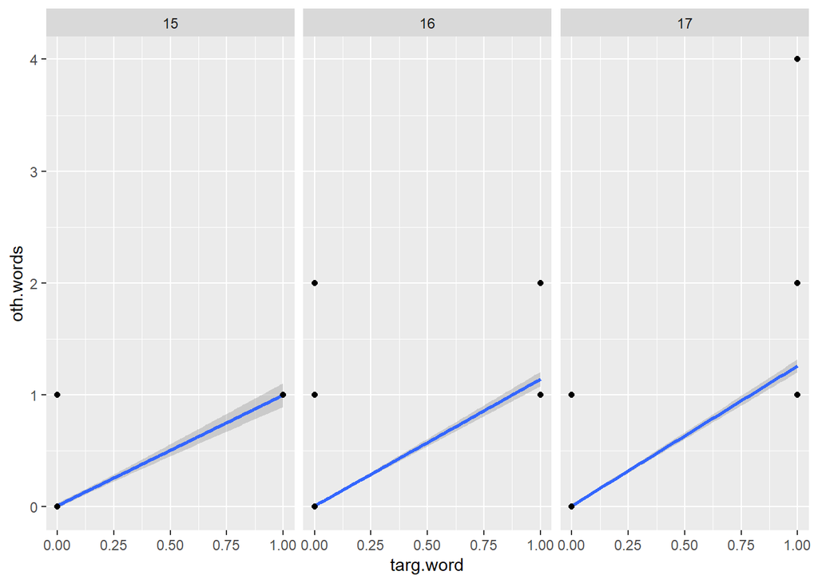

```r
slavdf %>%
  ggplot(aes(targ.word, oth.words))+
  geom_smooth(method="glm")+
  geom_point()+
  facet_wrap(~slavdf$century)
```

There is a correlation in texts of any century, but the angle of correlation line is changing. The main reason is the amount of possible oth.words values in 16th and 17th cc. texts compared to 15th, which again can be explained by their abundance in 16th and 17th cc.

### Conclusion

The initial hypothesis has been confirmed throughout the research. The presence of several Church Slavonic words in the sentence positively affects the probability of another Church Slavonic word to appear in the same sentence. There is a positive correlation between those two variables, which stays significant in any model tested during research.

However, there is still some ambiguity in the interpretation of century- and thematic domain-variables effects, which possibly was caused by the data bias.

In the future, I plan to replicate this experiment, with more precise preprocessing. For example, extract only those texts, which have the exact date, rather than compile data based on the century, and exclude thematic domain-variable entirely. Also the list of target words should be expanded.